# 経済セミナー 連載「実証ビジネス・エコノミクス」 第６回 「戦略は企業の特性が決める：参入ゲームの推定［応用編］」

# 5 Berry (1992)による推定

## 5.1 推定のためのデータ加工

- Berry (1992) の推定を行うために、以下のような手順でデータを加工する。
  - Step 0: 欠損のあるデータを削除
  - Step 1: シミュレーションに必要な変数を作成、参入の順番に並び替え
  - Step 2: 潜在的参入病院数を絞ってサブサンプル
  - Step 3: シミュレーションを行いやすくするためにデータを縦に長く加工
- Step 1, 3 については、それぞれの手順を関数として保存している。なぜなら、これらの手順は標準誤差を計算するためのブートストラップ法でも必要となるからである。
- Step 2は本来不要だが、今回は推定にかかる時間を短縮するためにサンプルを絞っている。

```r
# Step 0: 欠損のあるデータを削除
data_processed_pre <-
  data_cleaned %>%
  # 必要な変数のみ抽出
  dplyr::select(CityCode, Kyukyu, Kinou, Sien, Hyoka,
         DepNeurology, DepNeurosurgery, LogNumBeds,
         ZeroBedDum, DaigakuDum,
         Menseki, LogPop, LogIncome,
         MRIOwnDum) %>%
  # 欠損を含む観察を削除
  na.omit()
```

```r
# Step 1: シミュレーションに必要な変数を作成、参入の順番に並び替え
berry_process_data <- function(df){
  data_processed <-
    df %>%
    dplyr::arrange(CityCode) %>%
    # 各病院に乱数を振る
    dplyr::mutate(TieEntryOrder = runif(nrow(df))) %>%
    # 自治体毎の潜在的参入病院数、観察された参入病院数の変数を作成
    #（本誌のIm, Nmに対応）
    dplyr::group_by(CityCode) %>%
    dplyr::mutate(NumPotenHos = as.numeric(n()),
                  NumEntryObs = sum(MRIOwnDum)) %>%
    # データを参入の順番に並び替える
    # 病床数が多い順に並び替える。タイの場合は乱数を参照。
    # 注意: 参入順序の仮定は推定には不要だが、モデルによる予測や反実仮想分析では
    # 必要となるため、前もって初期の並び順を指定している。
    dplyr::arrange(desc(LogNumBeds), desc(TieEntryOrder),
                 .by_group = TRUE) %>%
    # incumbents move first の仮定の場合
    # dplyr::arrange(desc(MRIOwnDum), desc(LogNumBeds), desc(TieEntryOrder),
    #                .by_group = TRUE) %>%
    # 自治体毎に、参入した順番に沿った病院idを振る
    dplyr::mutate(EntryOrderId = as.numeric(1:NumPotenHos)) %>%
    dplyr::ungroup()
  return(data_processed)
}
```

```r
# 以降の結果が変わらないように、乱数を固定
set.seed(1)
# Step 1で作成した関数の実行
data_processed <- berry_process_data(data_processed_pre)
# 不要なオブジェクトを削除
rm(data_processed_pre)
```

```r
# Step 2: 潜在的参入病院数を絞ってサブサンプル
NumPotenHos_max <- 4
data_processed <- data_processed %>%
  # NumEntryObs_max 以下の観察に絞る
  dplyr::filter(EntryOrderId <= NumPotenHos_max) %>%
  # NumEntryObs, NumPotenHos の値を更新
  dplyr::group_by(CityCode) %>%
  dplyr::mutate(NumEntryObs = sum(MRIOwnDum),
                NumPotenHos = as.numeric(n())) %>%
  dplyr::ungroup()
```

- 各カテゴリーの病院のMRI保有割合（サブサンプル後のデータ）

```r
# 病院のカテゴリー毎に、総病院数、MRI所有病院数、その割合を確認
list(data_processed,
     data_processed %>% dplyr::filter(Kyukyu == 1),
     data_processed %>% dplyr::filter(Sien == 1),
     data_processed %>% dplyr::filter(Hyoka == 1),
     data_processed %>% dplyr::filter(DepNeurology == 1),
     data_processed %>% dplyr::filter(DepNeurosurgery == 1),
     # 元データの上位25%が1.2
     data_processed %>% dplyr::filter(LogNumBeds >= log(1.2)),
     data_processed %>% dplyr::filter(DaigakuDum == 1),
     data_processed %>% dplyr::filter(ZeroBedDum == 1)
     ) %>%
  purrr::map_dfr(.f =  per_MRI_cal) %>%
  dplyr::mutate(Category =
                  c('All', 'Kyukyu', 'Sien',
                    'Hyoka', 'DepNeurology', 'DepNeurosurgery',
                    'Top25%_NumBeds', 'DaigakuDum', 'ZeroBedDum')) %>%
  dplyr::relocate(Category, .before = Total) %>%
  kableExtra::kable(format = "html",
                    booktabs = TRUE) %>%
  kableExtra::kable_styling()
```

| Category | Total | MRIHos | PerMRI |
| --- | --- | --- | --- |
| All | 4112 | 2248 | 54.67 |
| Kyukyu | 2477 | 1744 | 70.41 |
| Sien | 151 | 141 | 93.38 |
| Hyoka | 1426 | 1096 | 76.86 |
| DepNeurology | 1272 | 1015 | 79.80 |
| DepNeurosurgery | 1696 | 1469 | 86.62 |
| Top25%_NumBeds | 1857 | 1629 | 87.72 |
| DaigakuDum | 125 | 115 | 92.00 |
| ZeroBedDum | 646 | 43 | 6.66 |

```r
# Step 3: シミュレーションを行いやすくするためにデータを縦に長く加工
# データの行数は \Sigma_{m = 1}^{M} (Im * Im) * nsとなる
berry_expand_data <- function(df, ns){
  # 自治体の数
  M <- df %>%
    dplyr::select(CityCode) %>%
    dplyr::n_distinct()
  # 病院の数（本誌のImのmについての和に対応）
  NumHos <- df %>%
    dplyr::distinct(CityCode, NumPotenHos) %>%
    dplyr::summarise(sum(NumPotenHos)) %>%
    as.numeric()

  # 誤差項をシミュレーション
  u_m0 <- rnorm(M * ns, mean = 0, sd = 1)
  u_mIm <- rnorm(NumHos * ns, mean = 0, sd = 1)
  u_df <- df %>%
    # 自治体、病院idのみのdataframeを作成
    dplyr::select(CityCode, EntryOrderId) %>%
    dplyr::group_by(CityCode) %>%
    nest() %>%
    # シミュレーション番号を振る（列数はns倍）
    tidyr::crossing(s = 1:ns) %>%
    # 自治体毎の誤差項の変数を作成
    dplyr::mutate(u_m0) %>%
    tidyr::unnest(cols = c(data)) %>%
    # 病院毎の誤差項の変数を作成
    dplyr::mutate(u_mIm)
  # 誤差項のdataframeを元のdataframeに統合
  data_expand <- df %>%
    dplyr::left_join(u_df, by = c('CityCode', 'EntryOrderId'))
  data_expand
  # シュミレーションで用いる、市場に存在する企業数の変数を作成（本誌のNに対応）
  # 自治体毎、病院毎に1からNumPotenHosまでの数を振るため、データが縦に長くなることに注意。
  num_entry_comb_df <-
    df %>%
    group_by(CityCode, EntryOrderId) %>%
    summarise(n_cand = 1:NumPotenHos,
              .groups = 'drop')
  data_expand <-
    data_expand %>%
    dplyr::left_join(num_entry_comb_df,
                     by = c('CityCode', 'EntryOrderId'))

  return(data_expand)
}
```

```r
# Step 3 で作成した関数の実行
ns <- 100
data_expand <-
  berry_expand_data(
    data_processed,
    ns)
```

## 5.2 Berry (1992) の目的関数の作成

```r
# データとパラメターを所与としたBerry (1992) の目的関数の値を計算する関数を作成
berry_obj <- function(params, df){
  # パラメター
  alpha <- params[1:8]
  beta <- params[9:12]
  delta <- params[13]
  rho <- params[14]
  # 可変利潤、固定費用の作成（本誌のvとphiに対応）
  df <- df %>%
    dplyr::mutate(
      var_profit =
        beta[1] + beta[2] * Menseki +
        beta[3] * LogPop + beta[4] * LogIncome +
        - delta * log(n_cand) +
        rho * u_m0,
      fixed_cost =
        alpha[1] * Kyukyu +
        alpha[2] * Sien + alpha[3] * Hyoka +
        alpha[4] * DepNeurology + alpha[5] * DepNeurosurgery +
        alpha[6] * LogNumBeds + alpha[7] * ZeroBedDum +
        alpha[8] * DaigakuDum +
        - sqrt(1 - rho ^2) * u_mIm
    )
  # Berry (1992) による手法の目的関数を計算する
  obj <- df %>%
    # Berry (1992) equation (12)に基づいて期待参入企業数を計算
    # 自治体、s、病院id、について、
    # 参入するかどうかの論理値型の列を作成
    dplyr::mutate(EntryDecision = var_profit > fixed_cost) %>%
    dplyr::group_by(CityCode, NumEntryObs, s, n_cand) %>%
    # 参入する企業数を計算
    dplyr::summarise(n_sim = sum(EntryDecision),
                     .groups = 'drop') %>%
    # 均衡条件を満たすNの候補を計算
    dplyr::mutate(eq_cond = ifelse(n_sim >= n_cand, 1, 0),
                  n_star = n_cand * eq_cond) %>%
    # 条件を満たす中で最も大きい値をN*とする
    dplyr::group_by(CityCode, NumEntryObs, s) %>%
    dplyr::summarise(n_star = max(n_star),
                     .groups = 'drop') %>%
    # 自治体について、期待参入企業数を計算
    dplyr::group_by(CityCode, NumEntryObs) %>%
    dplyr::summarise(n_exp = mean(n_star),
                     .groups = 'drop') %>%
    # 実際の参入病院数と比較し、誤差の二乗を計算
    dplyr::summarise(mean((NumEntryObs - n_exp)^2)) %>%
    as.numeric()
  return(obj)
}
```

## 5.3 推定

```r
# 係数の名前
est_names <-
  c('Kyukyu', 'Sien', 'Hyoka',
    'DepNeurology', 'DepNeurosurgery', 'LogNumBeds',
    'ZeroBedDum', 'DaigakuDum', 'Constant',
    'Menseki', 'LogPop', 'LogIncome',
    'delta', 'rho')
```

```r
# 初期値
param_init <-
  c(-0.587617,-1.298752,   -0.556557,
    -0.502602,   -1.058680,   -0.919110,
    -2.832720,   -2.726932,    1.937292,
    0.009940,    0.206644,   -1.617755,
    0.550239,    0.132202)
# Obj: 0.3666109
# berry_obj(params = param_init,
#           df = data_expand)
```

以上の初期値の元で推定を行う。

```r
tic.clearlog()
tic()
berry_result <-
  optim(params <- param_init,
        berry_obj,
        method = "Nelder-Mead",
        df = data_expand)
# rhoの符号を正しくする
berry_result$par <- berry_result$par %>%
  setNames(est_names)
berry_result$par[['rho']] <- abs(berry_result$par[['rho']])
berry_result$par <- berry_result$par %>% as.numeric()
toc()
```

```
## 401.44 sec elapsed
```

## 5.4 ブートストラップ法による標準誤差の計算

並列計算によってブートストラップを行う。

**留意点：** このブートストラップ計算には比較的時間がかかる点に留意されたい。並列計算に用いるコア数やCPUによっても異なるが、筆者のラップトップ(インテル Core i7-8650U、並列計算で６コア使用)の場合約３時間、ワークステーション(インテル Core i9-10980XE、並列計算で20コア使用)の場合約40分ほどかかる。計算時間や環境などに難がある方は、以下の2つのコードチャンクをスキップした上で、再現パッケージに含まれている`BootStrap_Berry_Result.rds`ファイルを用いて、以下のコードを読み進めてもらえれば幸いである。なお、RMDファイルにおける該当の2つのコードチャンクは`eval = FALSE`という設定にしているため、全体を走らせた場合には評価されない(コードとして実行されない)点に注意されたい。

最初のチャンクでは、並列計算のための設定を行う。ここで変数`cores`において、並列計算に使うCPUコア数を設定する。 なお、各ブートストラップサンプルにおける推定において乱数を利用するため、前と同様に乱数を固定する必要がある。しかしながら、並列計算の場合には`set.seed()`では乱数を固定することができない。ここではdoRNGパッケージにおける`registerDoRNG()`を利用する。

```r
# 並列計算のための設定を行う。
cores <- 20 #並列計算に使うCPUコアの個数。
registerDoParallel(cores)
registerDoRNG(12345)
```

並列計算によりブートストラップを行い、結果を保存する。並列計算には`foreach`を使う。

```r
# ブートストラップの回数
iter <- 100
# 自治体の数
M <- data_processed %>%
  dplyr::select(CityCode) %>%
  dplyr::n_distinct()
tic()
# 繰り返し推定を行う
bs_berry_result <-
  foreach::foreach (
    i = 1:iter,
    .export = ls(envir=parent.frame()),
      .packages = 'tidyverse'
    ) %dopar% {
      # リサンプルを行う
      bs_data <- data_processed %>%
        dplyr::distinct(CityCode) %>%
        dplyr::slice_sample(n = M, replace = TRUE) %>%
        dplyr::arrange(CityCode) %>%
        dplyr::mutate(id = 1:M) %>%
        dplyr::left_join(data_processed, by = 'CityCode') %>%
        # 推定ではCityCodeにより自治体を判別しているため名前を修正
        dplyr::rename(CityCodeOrigin = CityCode, CityCode = id)
      # リサンプルしたデータを推定のために加工
      bs_data_processed <-
        berry_process_data(bs_data)
      # 先程と同様に推定のためにデータを縦に広げる
      bs_data_expand <-
        berry_expand_data(
          bs_data_processed,
          ns)
      # 先程と同様に最適化により推定
      bs_berry_est <-
        optim(params <- param_init,
              berry_obj,
              method = "Nelder-Mead",
              df = bs_data_expand
              )$par
      # rhoの符号を正しくする
      bs_berry_est <- bs_berry_est %>%
        setNames(est_names)
      bs_berry_est[['rho']] <- abs(bs_berry_est[['rho']])
      return(bs_berry_est)
  }
toc()

# 結果を保存する。
saveRDS(bs_berry_result, file = "BootStrap_Berry_Result.rds")
```

ブートストラップの結果に基づいて標準誤差を計算する。

```r
bs_berry_result <- readRDS("BootStrap_Berry_Result.rds")

# 標準誤差を計算
berry_se <- bs_berry_result %>%
  map_dfr(~ unlist(as.data.frame(.))) %>%
  summarise(across(everything(), sd)) %>%
  as.numeric()
```

# 6 推定結果

## 6.1 推定結果の確認

```r
# 推定結果
tibble(
  name = c(est_names, 'Value of obj'),
  BR_est = c(berry_result$par, berry_result$value),
  # BR_se = berry_result_1129$BR_se
  BR_se = c(berry_se, NA)
  ) %>%
  dplyr::mutate(name = c('救急', '支援', '評価', '神経内科', '神経外科',
                         'log(病床数)', '病床0', '大学病院',
                         '定数項', '面積', 'log(人口)', 'log(課税所得)',
                         'delta', 'rho', '目的関数の値')) %>%
  kableExtra::kable(format = "html",
                    booktabs = TRUE,
                    caption = "Berry (1992) による推定結果",
                    col.names = c('変数', '推定値', '標準誤差'),
                    digits = 3) %>%
  kable_styling()
```

Berry (1992) による推定結果

| 変数 | 推定値 | 標準誤差 |
| --- | --- | --- |
| 救急 | -0.566 | 0.059 |
| 支援 | -1.117 | 0.090 |
| 評価 | -0.535 | 0.080 |
| 神経内科 | -0.485 | 0.109 |
| 神経外科 | -1.041 | 0.094 |
| log(病床数) | -0.925 | 0.034 |
| 病床0 | -2.816 | 0.159 |
| 大学病院 | -2.719 | 0.135 |
| 定数項 | 1.948 | 0.023 |
| 面積 | 0.005 | 0.014 |
| log(人口) | 0.212 | 0.014 |
| log(課税所得) | -1.607 | 0.031 |
| delta | 0.482 | 0.037 |
| rho | 0.150 | 0.149 |
| 目的関数の値 | 0.366 | NA |

## 6.2 モデルによる予測の確認

```r
# モデルによる参入予測確率を含めたdataframeを作成
predict_model <- function(df){
  data_predicted_pre <-
    df %>%
    # Berry (1992) equation (12)に基づいて期待参入企業数を計算
    # 自治体、s、病院id、について、
    # 参入するかどうかの論理値型の列を作成
    dplyr::mutate(EntryDecision = var_profit > fixed_cost) %>%
    dplyr::group_by(CityCode, NumEntryObs, s, n_cand) %>%
    # 参入する企業数を計算
    dplyr::summarise(n_sim = sum(EntryDecision),
                     .groups = 'drop') %>%
    # 均衡条件を満たすNの候補を計算
    dplyr::mutate(eq_cond = ifelse(n_sim >= n_cand, 1, 0),
                  n_star = n_cand * eq_cond) %>%
    # 条件を満たす中で最も大きい値をN*とする
    dplyr::group_by(CityCode, NumEntryObs, s) %>%
    dplyr::summarise(n_star = max(n_star),
                     .groups = 'drop') %>%
    dplyr::select(-NumEntryObs) %>%
    # 元のdata.frameにn_starを含むdata.frameをjoin
    dplyr::right_join(
      df %>%
        dplyr::select(-n_cand) %>%
        dplyr::distinct(across(everything())),
      by = c('CityCode', 's')
    ) %>%
    # 参入順序の仮定に基づいて、それぞれの企業が参入するかどうかを決める
    dplyr::mutate(EntryCond = ifelse(n_star >= EntryOrderId, 1, 0)) %>%
    # 参入の予測確率を計算
    dplyr::group_by(CityCode, EntryOrderId) %>%
    dplyr::summarise(EntryProb = mean(EntryCond),
                     .groups = 'drop') %>%
    dplyr::mutate(EntryPred = ifelse(EntryProb >= 0.5 ,1 ,0))

  # 各企業が参入するかどうかを示す列を含むdata.frameを、元のdata.frameにmergeする
  data_predicted <-
    df %>%
    dplyr::select(-c(s, u_m0, u_mIm, n_cand, var_profit, fixed_cost)) %>%
    dplyr::distinct(across(everything())) %>%
    dplyr::left_join(data_predicted_pre,
                     by = c('CityCode', 'EntryOrderId'))
  return(data_predicted)
}
```

```r
# 推定したパラメターを取得
berry_est <- berry_result$par
# パラメター
alpha <- berry_est[1:8]
beta <- berry_est[9:12]
delta <- berry_est[13]
rho <- berry_est[14]

data_expand <-
  data_expand %>%
  # 可変利潤、固定費用の作成（本誌のvとphiに対応）
  dplyr::mutate(
    var_profit =
      beta[1] + beta[2] * Menseki +
      beta[3] * LogPop + beta[4] * LogIncome +
      - delta * log(n_cand) +
      rho * u_m0,
    fixed_cost =
      alpha[1] * Kyukyu  +
      alpha[2] * Sien + alpha[3] * Hyoka +
      alpha[4] * DepNeurology + alpha[5] * DepNeurosurgery +
      alpha[6] * LogNumBeds + alpha[7] * ZeroBedDum +
      alpha[8] * DaigakuDum +
      - sqrt(1 - rho ^2) * u_mIm,
  )
```

```r
data_predicted <-
  data_expand %>%
  predict_model()
```

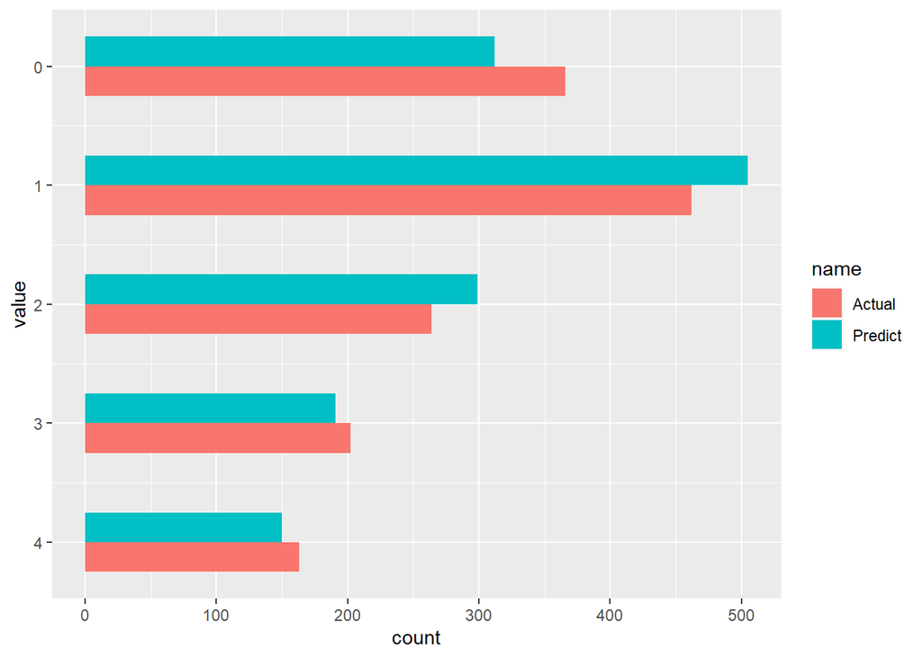

```r
# 参入病院数毎に、自治体がいくつ観察されるかを集計
data_predicted %>%
  dplyr::group_by(CityCode) %>%
  dplyr::summarise(Actual = sum(MRIOwnDum),
                   Predict = sum(EntryPred)) %>%
  tidyr::pivot_longer(cols = c('Actual', 'Predict')) %>%
  ggplot2::ggplot(aes(x = value, fill = name)) +
  ggplot2::geom_histogram(binwidth = 0.5,
                          position = "dodge") +
  coord_flip() +
  scale_x_reverse()
```

```r
# 以下の表を作成するための関数
actual_pred_cal <- function(df){
  df %>%
    dplyr::summarise(Actual = sum(MRIOwnDum),
                     Predict = sum(EntryPred))
}
```

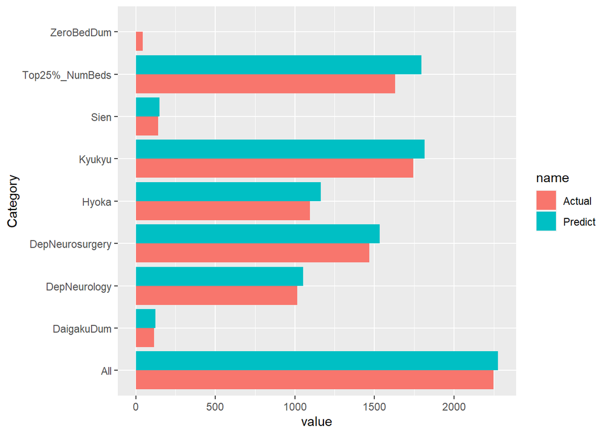

```r
# 病院のタイプ別の観察された参入病院数と予測された参入病院数
list(data_predicted,
     data_predicted %>% dplyr::filter(Kyukyu == 1),
     data_predicted %>% dplyr::filter(Sien == 1),
     data_predicted %>% dplyr::filter(Hyoka == 1),
     data_predicted %>% dplyr::filter(DepNeurology == 1),
     data_predicted %>% dplyr::filter(DepNeurosurgery == 1),
     # 元データの上位25%が1.2
     data_predicted %>% dplyr::filter(LogNumBeds >= log(1.2)),
     data_predicted %>% dplyr::filter(DaigakuDum == 1),
     data_predicted %>% dplyr::filter(ZeroBedDum == 1)
     ) %>%
  purrr::map_dfr(.f =  actual_pred_cal) %>%
  dplyr::mutate(Category =
                  c('All', 'Kyukyu', 'Sien',
                    'Hyoka', 'DepNeurology', 'DepNeurosurgery',
                    'Top25%_NumBeds', 'DaigakuDum', 'ZeroBedDum')) %>%
  tidyr::pivot_longer(cols = c('Actual', 'Predict')) %>%
  ggplot2::ggplot(aes(x = Category, y = value, fill = name)) +
  geom_bar(position="dodge", stat = "identity") +
  coord_flip()
```

```r
  # theme_minimal()
```

```r
# 特定の病院について平均二乗誤差を表示
tibble(
  category = c('Total', 'DepNeurology', 'DepNeurosurgery', 'ZeroBedDum', 'DaigakuDum'),
  mse = c(data_predicted %>%
            dplyr::summarise(mean((MRIOwnDum - EntryProb) ^ 2)) %>%
            as.numeric() %>% round(3),
          data_predicted %>%
            dplyr::filter(DepNeurology == 1) %>%
            dplyr::summarise(mean((MRIOwnDum - EntryProb) ^ 2)) %>%
            as.numeric() %>% round(3),
          data_predicted %>%
            dplyr::filter(DepNeurosurgery == 1) %>%
            dplyr::summarise(mean((MRIOwnDum - EntryProb) ^ 2)) %>%
            as.numeric() %>% round(3),
          data_predicted %>%
            dplyr::filter(ZeroBedDum == 1) %>%
            dplyr::summarise(mean((MRIOwnDum - EntryProb) ^ 2)) %>%
            as.numeric() %>% round(3),
          data_predicted %>%
            dplyr::filter(DaigakuDum == 1) %>%
            dplyr::summarise(mean((MRIOwnDum - EntryProb) ^ 2)) %>%
            as.numeric() %>% round(3)
          )
)
```

| category | mse |
| --- | --- |
| Total | 0.146 |
| DepNeurology | 0.119 |
| DepNeurosurgery | 0.115 |
| ZeroBedDum | 0.066 |
| DaigakuDum | 0.081 |

# 7 反実仮想分析

推定では企業の参入順序を仮定する必要がなかったが、反実仮想分析においては、どの企業が参入するかを観察したいため、企業の参入順序を仮定する必要がある。そこで、以下では３つの参入順序を考えて分析を行っている。

## 7.1 参入順序: 病床数

病床数が多い順に参入すると仮定する。タイはランダムとしている。

```r
# 神経内科と神経外科を持つ病院はMRIの所有を義務付けられたとする
# MRI所有義務化病院が既に参入しているとして、他の病院が参入するかどうかをシミュレート
data_cf <-
  data_expand %>%
  dplyr::group_by(CityCode, s, n_cand) %>%
  # MRI所有義務化病院が先になるように並び替える
  dplyr::arrange(desc(DepNeurology), desc(DepNeurosurgery),
                 desc(LogNumBeds), desc(TieEntryOrder),
                 .by_group = TRUE) %>%
  # 参入する順番を更新する
  dplyr::mutate(EntryOrderId = as.numeric(1:NumPotenHos)) %>%
  dplyr::ungroup() %>%
  # 反実仮想分析の処理: MRI所有義務化病院が必ず参入するために大学病院の利潤を大きな値に置き換え
  dplyr::mutate(var_profit =
                  ifelse(DepNeurology == 1 | DepNeurosurgery == 1
                         , 10^5, var_profit)) %>%
  predict_model()
```

```r
# 以下の表を作成するための関数
per_decline_cal <- function(df){
  df %>%
    dplyr::summarise(
      Total = n(),
      Actual = sum(MRIOwnDum),
      Fit_Pred = sum(Fit_Pred),
      CF_Pred = sum(EntryPred),
      CF_Pred_am_actual = sum(MRIOwnDum * EntryPred)
      )
}
```

```r
# 病院のカテゴリー毎に、総病院数(Total)、
# 元のモデルにより予測されたMRI所有病院数(Fit_Pred)、
# 反実仮想分析により予測されたMRI所有病院数(CF_Pred)、
# MRI所有病院数の変化率(PerChange)、を確認
generate_cf_result <- function(data_predicted, data_cf){
  data_cf_sub <-
    data_cf %>%
    # 元のモデルでの参入の予測を表す変数を加える
    dplyr::left_join(data_predicted %>%
                       dplyr::select(CityCode, TieEntryOrder, EntryPred) %>%
                       dplyr::rename(Fit_Pred = EntryPred),
                     by = c("CityCode", "TieEntryOrder")) %>%
    # 政策の対象かどうかを表すダミー
    dplyr::mutate(PolicyTarget =
                    ifelse(
                      (DepNeurology == 1 | DepNeurosurgery == 1) & Fit_Pred != 1,
                      #DepNeurology == 1 | DepNeurosurgery == 1) & MRIOwnDum != 1,
                      1, 0)
    ) %>%
    dplyr::filter(PolicyTarget == 0)

  list(data_cf_sub,
       data_cf_sub %>% dplyr::filter(Kyukyu == 1),
       data_cf_sub %>% dplyr::filter(Sien == 1),
       data_cf_sub %>% dplyr::filter(Hyoka == 1),
       data_cf_sub %>% dplyr::filter(DepNeurology == 1),
       data_cf_sub %>% dplyr::filter(DepNeurosurgery == 1),
       data_cf_sub %>% dplyr::filter(!(DepNeurology == 1 | DepNeurosurgery == 1)),
       # 元データの上位25%が1.2
       data_cf_sub %>% dplyr::filter(LogNumBeds >= log(1.2)),
       data_cf_sub %>% dplyr::filter(DaigakuDum == 1),
       data_cf_sub %>% dplyr::filter(ZeroBedDum == 1)
  ) %>%
    purrr::map_dfr(.f =  per_decline_cal) %>%
    dplyr::mutate(Category =
                    c('All', 'Kyukyu', 'Sien', 'Hyoka',
                      'DepNeurology', 'DepNeurosurgery',
                      'Not_(DepNeurology_and_DepNeurosurgery)',
                      'Top25%_NumBeds', 'DaigakuDum', 'ZeroBedDum')) %>%
    dplyr::select(Category, Fit_Pred, CF_Pred) %>%
    dplyr::mutate(PerChange = round((CF_Pred/Fit_Pred - 1) * 100, 2)) %>%
    kableExtra::kable(format = "html",
                      booktabs = TRUE,
                      digits = 3) %>%
    kableExtra::kable_styling()
}
```

```r
generate_cf_result(data_predicted, data_cf)
```

| Category | Fit_Pred | CF_Pred | PerChange |
| --- | --- | --- | --- |
| All | 2276 | 2193 | -3.65 |
| Kyukyu | 1815 | 1782 | -1.82 |
| Sien | 149 | 149 | 0.00 |
| Hyoka | 1164 | 1144 | -1.72 |
| DepNeurology | 1053 | 1053 | 0.00 |
| DepNeurosurgery | 1533 | 1533 | 0.00 |
| Not_(DepNeurology_and_DepNeurosurgery) | 491 | 408 | -16.90 |
| Top25%_NumBeds | 1795 | 1777 | -1.00 |
| DaigakuDum | 124 | 124 | 0.00 |
| ZeroBedDum | 1 | 1 | 0.00 |

## 7.2 参入順序: 既存企業

データ上で参入が観察された企業から行動すると仮定する。タイはランダムとしている。

```r
data_predicted_order2 <-
  data_expand %>%
  dplyr::group_by(CityCode, s, n_cand) %>%
  # 既存企業、病床数の順に並び替え
  dplyr::arrange(desc(MRIOwnDum),
                 desc(LogNumBeds), desc(TieEntryOrder),
                 .by_group = TRUE) %>%
  # 参入する順番を更新する
  dplyr::mutate(EntryOrderId = as.numeric(1:NumPotenHos)) %>%
  dplyr::ungroup() %>%
  predict_model()
```

```r
data_cf_order2 <-
  data_expand %>%
  dplyr::group_by(CityCode, s, n_cand) %>%
  # MRI所有義務化病院が先になるように並び替える
  dplyr::arrange(desc(DepNeurology), desc(DepNeurosurgery),
                 desc(MRIOwnDum),
                 desc(LogNumBeds), desc(TieEntryOrder),
                 .by_group = TRUE) %>%
  # 参入する順番を更新する
  dplyr::mutate(EntryOrderId = as.numeric(1:NumPotenHos)) %>%
  dplyr::ungroup() %>%
  # 反実仮想分析の処理: MRI所有義務化病院が必ず参入するために大学病院の利潤を大きな値に置き換え
  dplyr::mutate(var_profit =
                  ifelse(DepNeurology == 1 | DepNeurosurgery == 1
                         , 10^5, var_profit)) %>%
  predict_model()
```

```r
generate_cf_result(data_predicted_order2, data_cf_order2)
```

| Category | Fit_Pred | CF_Pred | PerChange |
| --- | --- | --- | --- |
| All | 2276 | 2219 | -2.50 |
| Kyukyu | 1808 | 1783 | -1.38 |
| Sien | 147 | 147 | 0.00 |
| Hyoka | 1148 | 1139 | -0.78 |
| DepNeurology | 1065 | 1065 | 0.00 |
| DepNeurosurgery | 1549 | 1549 | 0.00 |
| Not_(DepNeurology_and_DepNeurosurgery) | 465 | 408 | -12.26 |
| Top25%_NumBeds | 1755 | 1750 | -0.28 |
| DaigakuDum | 124 | 124 | 0.00 |
| ZeroBedDum | 11 | 8 | -27.27 |

## 7.3 参入順序: ランダム

ランダムに参入すると仮定する。

```r
random_entry_df <-
  data_expand %>%
  dplyr::distinct(CityCode, EntryOrderId) %>%
  mutate(RandomEntryOrder = runif(n(),0,1))
```

```r
data_predicted_order3 <-
  data_expand %>%
  dplyr::left_join(random_entry_df,
                   by = c('CityCode', 'EntryOrderId')) %>%
  dplyr::group_by(CityCode, s, n_cand) %>%
  # ランダムに並び替え
  dplyr::arrange(desc(RandomEntryOrder),
                 .by_group = TRUE) %>%
  # 参入する順番を更新する
  dplyr::mutate(EntryOrderId = as.numeric(1:NumPotenHos)) %>%
  dplyr::ungroup() %>%
  predict_model()
```

```r
data_cf_order3 <-
  data_expand %>%
  dplyr::left_join(random_entry_df,
                   by = c('CityCode', 'EntryOrderId')) %>%
  dplyr::group_by(CityCode, s, n_cand) %>%
  # MRI所有義務化病院が先になるように並び替える
  dplyr::arrange(desc(DepNeurology), desc(DepNeurosurgery),
                 desc(RandomEntryOrder),
                 .by_group = TRUE) %>%
  # 参入する順番を更新する
  dplyr::mutate(EntryOrderId = as.numeric(1:NumPotenHos)) %>%
  dplyr::ungroup() %>%
  # 反実仮想分析の処理: MRI所有義務化病院が必ず参入するために大学病院の利潤を大きな値に置き換え
  dplyr::mutate(var_profit =
                  ifelse(DepNeurology == 1 | DepNeurosurgery == 1
                         , 10^5, var_profit)) %>%
  predict_model()
```

```r
generate_cf_result(data_predicted_order3, data_cf_order3)
```

| Category | Fit_Pred | CF_Pred | PerChange |
| --- | --- | --- | --- |
| All | 2276 | 1879 | -17.44 |
| Kyukyu | 1559 | 1437 | -7.83 |
| Sien | 115 | 115 | 0.00 |
| Hyoka | 977 | 914 | -6.45 |
| DepNeurology | 899 | 899 | 0.00 |
| DepNeurosurgery | 1224 | 1224 | 0.00 |
| Not_(DepNeurology_and_DepNeurosurgery) | 805 | 408 | -49.32 |
| Top25%_NumBeds | 1369 | 1333 | -2.63 |
| DaigakuDum | 102 | 102 | 0.00 |
| ZeroBedDum | 192 | 64 | -66.67 |